# Experiment of DriveML R package - Small Data set

Dayanand, Sayan, Ravi, Kiran R

16/06/2021

```r
library(DriveML)    ## automl package
library(data.table) ## data wrangling package
library(caret)      ## ML wrapper package
library(mlr)        ## ML wrapper package
library(h2o)        ## automl package
library(OneR)       ## automl package
library(Metrics)    ## auc function
library(autoxgboost)## automl package
```

## Heart Disease UCI

data source : **https://archive.ics.uci.edu/ml/datasets/Heart+Disease**

#### Content

This database contains 76 attributes, but all published experiments refer to using a subset of 14 of them. In particular, the Cleveland database is the only one that has been used by ML researchers to this date. The “goal” field refers to the presence of heart disease in the patient. It is integer valued from 0 (no presence) to 4.

**Acknowledgements:**

Creators:

Hungarian Institute of Cardiology. Budapest: Andras Janosi, M.D. University Hospital, Zurich, Switzerland: William Steinbrunn, M.D. University Hospital, Basel, Switzerland: Matthias Pfisterer, M.D. V.A. Medical Center, Long Beach and Cleveland Clinic Foundation: Robert Detrano, M.D., Ph.D. Donor: David W. Aha (aha ‘@’ ics.uci.edu) (714) 856-8779

# DriveML Experiment

```r
data_path = "C:/backup/R packages/DriveML_Experiments/small_data_heart_desease"
heart_data <- fread(paste0(data_path, "/","heart.csv"), sep = ",",header = TRUE)

##target variable distributions
table(heart_data$target_var)
```

```
##
##   0   1
## 138 165
```

#### Split sample to test the model accuaracy with other open source R package

```r
set.seed(1991)
train.index <- createDataPartition(heart_data$target_var, p = .8, list = FALSE)
```

#### DriveML step 1 - Missing variable treatment

```r
marobj <- autoMAR (heart_data, aucv = 0.9, strataname = NULL, stratasize = NULL, mar_method="glm")
marobj$auc_features
```

#### DriveML step 2 - Auto Dataprep

```r
## Type of missing imputation
myimpute <- list(classes=list(factor = imputeMode(),
                              integer = imputeMean(),
                              numeric = imputeMedian(),
                              character = imputeMode()))

## AutoDataprep
traindata <- autoDataprep(heart_data, target = "target_var",
                          auto_mar = TRUE,
                          mar_object=marobj,
                          missimpute = myimpute,
                          dummyvar = TRUE,
                          aucv = 0.002, corr = 0.999,
                          outlier_flag = TRUE,
                          char_var_limit = 150,
                          interaction_var = TRUE,
                          frequent_var = TRUE,
                          verbose =TRUE)
```

```
## autoDataprep < Outlier treatment based on Tukey method....>
## autoDataprep < Interactions transformer....>
## autoDataprep < Categorical variable - one hot encoding....>
## autoDataprep < variable reduction - zero variance method.... >
## autoDataprep < variable selection - pearson correlation method.... >
## autoDataprep < variable selection - AUC method.... >
```

```r
master_heart_data <- traindata$master_data
sele_var <- traindata$var_list$mydata_var
heart_train_data <- master_heart_data[sele_var]

### Train and valid data
train_heart <- heart_train_data[train.index,]
valid_heart <- heart_train_data[-train.index,]
```

#### DriveML step 3 - Model development

```r
mymodel_heart <- autoMLmodel( train = train_heart,
                           test = valid_heart,
                           target = 'target_var',
                           tuneIters = 10,
                           tuneType = "random",
                           models = "all",
                           varImp = 10,
                           liftGroup = 50,
                           maxObs = 5000,
                           htmlreport = FALSE,
                           verbose = TRUE,
                           seed = 1991)
  save(mymodel_heart, file="small_data_mymodel.rdata")
```

#### DriveML Results

**Model results**

```r
results <- mymodel_heart$results
kableExtra::kable(results)
```

| Model | Fitting time | Scoring time | Train AUC | Test AUC | Accuracy | Precision | Recall | F1_score |
| --- | --- | --- | --- | --- | --- | --- | --- | --- |
| glmnet | 3.051 secs | 0.008 secs | 0.925 | 0.917 | 0.767 | 0.737 | 0.875 | 0.800 |
| logreg | 2.347 secs | 0.009 secs | 0.952 | 0.708 | 0.750 | 0.707 | 0.906 | 0.795 |
| randomForest | 2.553 secs | 0.008 secs | 0.982 | 0.939 | 0.817 | 0.784 | 0.906 | 0.841 |
| ranger | 2.567 secs | 0.03 secs | 0.996 | 0.927 | 0.800 | 0.778 | 0.875 | 0.824 |
| xgboost | 3.013 secs | 0.006 secs | 0.999 | 0.868 | 0.750 | 0.743 | 0.812 | 0.776 |
| rpart | 2.211 secs | 0.008 secs | 0.941 | 0.875 | 0.783 | 0.788 | 0.812 | 0.800 |

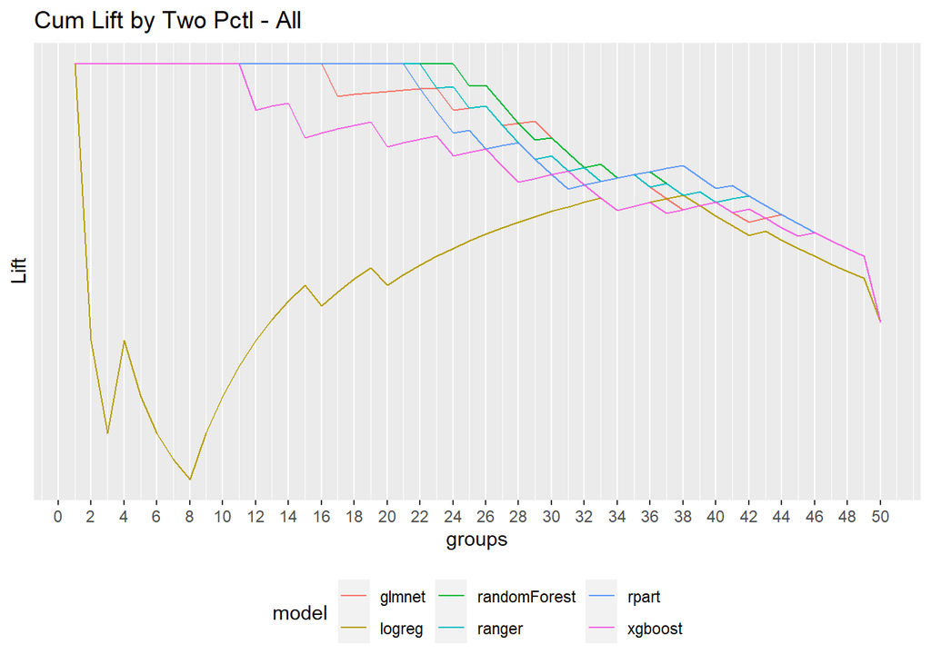

```r
## Variable Lift
mymodel_heart$modelexp$Lift_plot
```

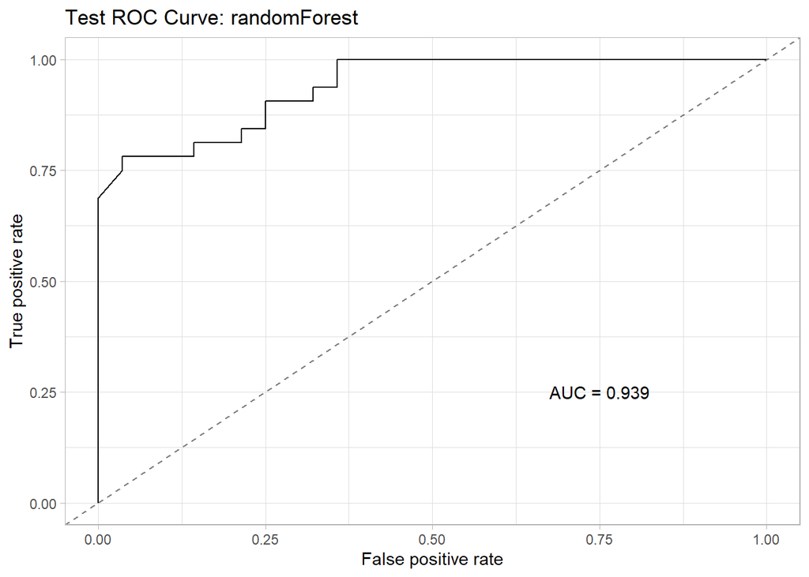

```r
### Random Forest Model validation ROC
mymodel_heart$trainedModels$randomForest$modelPlots$TestROC
```

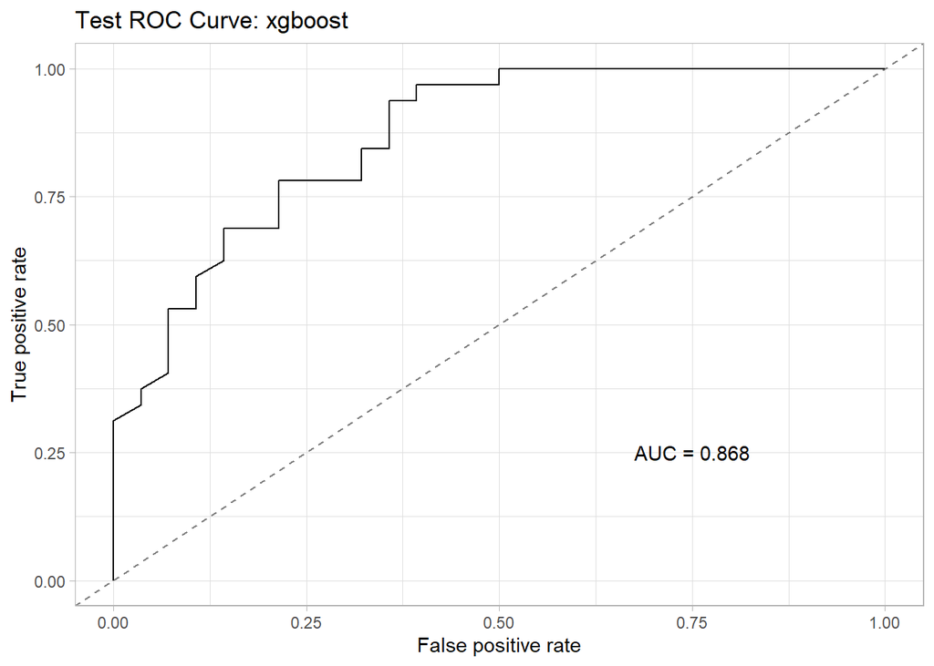

```r
### XGBoost Model validation ROC
mymodel_heart$trainedModels$xgboost$modelPlots$TestROC
```

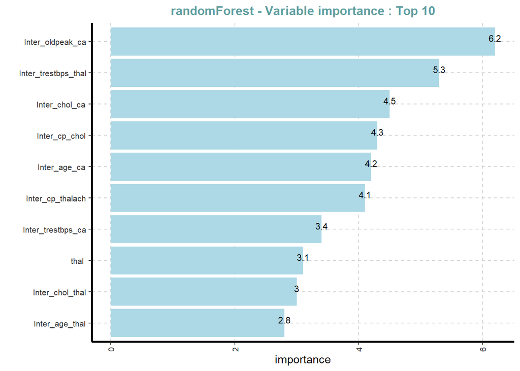

```r
### Random Forest Model Variable Importance
mymodel_heart$trainedModels$randomForest$modelPlots$VarImp
```

# Best ML model comparison with other R packages

### 1. DriveML

available on CRAN and git

selected best model from driveml outcome

```r
time <- Sys.time()
## Type of missing imputation
myimpute <- list(classes=list(factor = imputeMode(),
                              integer = imputeMean(),
                              numeric = imputeMedian(),
                              character = imputeMode()))

## AutoDataprep
traindata <- autoDataprep(heart_data, target = "target_var",
                          dummyvar = TRUE,
                          aucv = 0.002, corr = 0.999,
                          outlier_flag = TRUE,
                          char_var_limit = 150,
                          interaction_var = TRUE,
                          frequent_var = TRUE,
                          verbose =TRUE)
```

```
## autoDataprep < Outlier treatment based on Tukey method....>
## autoDataprep < Interactions transformer....>
## autoDataprep < Categorical variable - one hot encoding....>
## autoDataprep < variable reduction - zero variance method.... >
## autoDataprep < variable selection - pearson correlation method.... >
## autoDataprep < variable selection - AUC method.... >
```

```r
master_heart_data <- traindata$master_data
sele_var <- traindata$var_list$mydata_var
heart_train_data <- master_heart_data[sele_var]

### Train and valid data
train_heart <- heart_train_data[train.index,]
valid_heart <- heart_train_data[-train.index,]

driveml_smalldata <- autoMLmodel( train = train_heart,
                           test = valid_heart,
                           target = 'target_var',
                           tuneIters = 10,
                           tuneType = "random",
                           models = "randomforest",
                           varImp = 10,
                           liftGroup = 50,
                           maxObs = 5000,
                           htmlreport = FALSE,
                           verbose = TRUE,
                           seed = 1991)
```

```
## randomForest Model tuning started....
## autoMLmodel < All features randomForest tuned and trained >
```

```r
dtime <- round(difftime(Sys.time(), time, units='secs'),3)
```

```r
bestroc <- round(driveml_smalldata$results$`Test AUC`,3)

comparision_metric <- matrix(data=NA, nrow=4, ncol=8)
colnames(comparision_metric) <- c("r_package_name","dataset_name","attributes","missing","Train_instances","Test_instances", "time_taken_min", "test_auc")

comparision_metric[1,"dataset_name"] <- "Small data"
comparision_metric[1,"r_package_name"] <- "DriveML"
comparision_metric[1,"time_taken_min"] <- dtime
comparision_metric[1,"test_auc"] <- bestroc
comparision_metric[1,"attributes"] <- 14
comparision_metric[1,"missing"] <- "No"
comparision_metric[1,"Train_instances"] <- 243
comparision_metric[1,"Test_instances"] <- 60
```

### 2. H2o AutoML

available on CRAN and git

```r
setDF(heart_data)
## Convert character data to factor for H2o automl function
heart_data[sapply(heart_data, is.character)] <- lapply(heart_data[sapply(heart_data, is.character)], as.factor)

## Convert target class variable as factor
## For binary classification, response should be a factor
heart_data$target_var <- as.factor(heart_data$target_var)

### Train and valid data
train_heart <- heart_data[train.index,]
valid_heart <- heart_data[-train.index,]
```

Training using h2o.automl() function

```r
h2o.init()
```

[output not shown]

```r
## train and valid data set inot h2o
time = Sys.time() ## start time
train_d = as.h2o(train_heart)
test_d = as.h2o(valid_heart)
```

Train Model

```r
h2o_small_data_model <- h2o.automl(y = "target_var",
                        training_frame = train_d,
                        validation_frame = test_d,
                        max_models = 5L,
                        exclude_algos = c("GLM", "DeepLearning", "DRF","StackedEnsemble"))
```

[output not shown]

```r
lb = as.data.frame(h2o_small_data_model@leaderboard)
best_auc <- round(lb$auc[1],3)
time_h2o <- round(difftime(Sys.time(), time, units='secs'),3)
save(h2o_small_data_model, file = "h2o_model_small_data_heart_ana.rdata")

comparision_metric[2,"dataset_name"] <- "Small data"
comparision_metric[2,"r_package_name"] <- "H2o automl"
comparision_metric[2,"time_taken_min"] <- time_h2o
comparision_metric[2,"test_auc"] <- best_auc
comparision_metric[2,"attributes"] <- 14
comparision_metric[2,"missing"] <- "No"
comparision_metric[2,"Train_instances"] <- 243
comparision_metric[2,"Test_instances"] <- 60
```

### 3. OneR

available on CRAN and git

build model with the OneR package

```r
## Read Raw data
data_path = "C:/backup/R packages/DriveML_Experiments/small_data_heart_desease"
heart_data <- fread(paste0(data_path, "/","heart.csv"), sep = ",",header = TRUE)

## Recode target variable
time = Sys.time() ## Start time
setDF(heart_data) # set as data frame


### Train and valid data
train_heart <- heart_data[train.index,]
valid_heart <- heart_data[-train.index,]

## OneR model
model_oner_large <- OneR(target_var ~., data = train_heart, verbose = TRUE)
```

```
##
##     Attribute Accuracy
## 1 * thal      78.19%
## 2   cp        74.07%
## 3   ca        73.66%
## 4   exang     71.19%
## 5   thalach   70.78%
## 5   slope     70.78%
## 7   oldpeak   67.9%
## 8   age       63.79%
## 9   sex       61.73%
## 10  restecg   58.02%
## 11  trestbps  57.2%
## 12  chol      53.91%
## 13  fbs       53.5%
## ---
## Chosen attribute due to accuracy
## and ties method (if applicable): '*'
```

```r
prediction_oner <- predict(model_oner_large, valid_heart,type = c("prob"))
small_data_onertime <- round(difftime(Sys.time(), time, units='secs'),3)
save(model_oner_large, file = "oner_model_small_data_heart_ana.rdata")
summary(model_oner_large)
```

```
##
## Call:
## OneR.formula(formula = target_var ~ ., data = train_heart, verbose = TRUE)
##
## Rules:
## If thal = 0 then target_var = 0
## If thal = 1 then target_var = 0
## If thal = 2 then target_var = 1
## If thal = 3 then target_var = 0
##
## Accuracy:
## 190 of 243 instances classified correctly (78.19%)
##
## Contingency table:
##           thal
## target_var   0    1     2    3 Sum
##        0   * 1 * 11    25 * 76 113
##        1     1    5 * 102   22 130
##        Sum   2   16   127   98 243
## ---
## Maximum in each column: '*'
##
## Pearson's Chi-squared test:
## X-squared = 77.882, df = 3, p-value < 2.2e-16
```

```r
best_auc_oner <- round(auc(valid_heart$target_var, prediction_oner[,"1"]),2)
```

```r
comparision_metric[3,"dataset_name"] <- "Small data"
comparision_metric[3,"r_package_name"] <- "OneR"
comparision_metric[3,"time_taken_min"] <- small_data_onertime
comparision_metric[3,"test_auc"] <- best_auc_oner
comparision_metric[3,"attributes"] <- 14
comparision_metric[3,"missing"] <- "No"
comparision_metric[3,"Train_instances"] <- 243
comparision_metric[3,"Test_instances"] <- 60
```

### 4. autoxgboost

available on git

**devtools::install_github(“ja-thomas/autoxgboost”)**

```r
## Using DriveML autodataprep create a cleaned data set
data_path = "C:/backup/R packages/DriveML_Experiments/small_data_heart_desease"
heart_data <- fread(paste0(data_path, "/","heart.csv"), sep = ",",header = TRUE)

## Recode target variable
time = Sys.time() ## Start time
setDF(heart_data) # set as data frame


### Train and valid data
train_heart <- heart_data[train.index,]
valid_heart <- heart_data[-train.index,]
```

```r
# create a classification task
train_heart$target_var <- as.factor(train_heart$target_var)

trainTask = makeClassifTask(data = train_heart, target = "target_var", positive = 1)
# create a control object for optimizer
time = Sys.time()
ctrl = makeMBOControl()
ctrl = setMBOControlTermination(ctrl, iters = 1L)
# fit the model
auto_xgb_model = autoxgboost(trainTask, control = ctrl, tune.threshold = TRUE)
tot_time = round(difftime(Sys.time(), time, units='secs'),3)
```

```r
# do prediction and print confusion matrix
valid_heart_x <- valid_heart
valid_heart_x$target_var <- NULL
prediction = predict(auto_xgb_model, valid_heart_x)
prediction = getPredictionProbabilities(prediction)

myauc = round(auc(valid_heart$target_var, prediction),3)
save(auto_xgb_model, file = "axgb_model_small_data_heart_ana.rdata")

comparision_metric[4,"dataset_name"] <- "Small data"
comparision_metric[4,"r_package_name"] <- "autoxgboost"
comparision_metric[4,"time_taken_min"] <- tot_time
comparision_metric[4,"test_auc"] <- myauc
comparision_metric[4,"attributes"] <- 14
comparision_metric[4,"missing"] <- "No"
comparision_metric[4,"Train_instances"] <- 243
comparision_metric[4,"Test_instances"] <- 60
```

## Comparision results

```r
kableExtra::kable(comparision_metric)
```

| r_package_name | dataset_name | attributes | missing | Train_instances | Test_instances | time_taken_min | test_auc |
| --- | --- | --- | --- | --- | --- | --- | --- |
| DriveML | Small data | 14 | No | 243 | 60 | 6.073 | 0.914 |
| H2o automl | Small data | 14 | No | 243 | 60 | 32.066 | 0.906 |
| OneR | Small data | 14 | No | 243 | 60 | 0.045 | 0.68 |
| autoxgboost | Small data | 14 | No | 243 | 60 | 10.288 | 0.902 |